# Session 1: Introduction

## How I will work

I tend to jump back and forth between the slides and RStudio

### Slides

[figure not shown]

See the rendered slides on: https://jbgruber.github.io/ess-web-scraping-data-management/

### Source

[figure not shown]

See the qmd file in each session folder

## Use the course marerial

1. Pull the latest version at the beginning of each session
2. Make a copy of the qmd file and name it, e.g., “1_Introduction_notes.qmd”
3. Use this file to make notes, for example by adding comments using this syntax `<!-- your comment -->` (RStudio shortcut Ctrl + Shift + C / Command + Shift + C on macOS)
- Alternatively, you can annotate a PDF version of the slides by heading to the [website](https://jbgruber.github.io/ess-web-scraping-data-management/), clicking on the slides you want, then press `e` to export them to PDF (and take notes with PDF reader)

**Warning**

This is to make sure you don’t get any **git conflicts** when you pull and I updated something in the material in the meantime.

## Your turn (Exercises 1)

1. Download the course material and open the RStudio project or folder in your IDE
2. Open the file `readme.qmd` from the file explorer of your IDE
3. Execute the final code Chunk to install all packages we will need for this course

# Using AI in this course

## Skills

- I don’t mind if you use AI (Claude (Code), ChaGPT, etc.)
- Just make sure you are still picking up new skills
- E.g., ask the LLM to *explain*, not *write* code (including asking for help if things)
- If the LLM write code, make sure you understand everything it is doing (if you don’t see previous bullet)
- Goal: **you know how to recognize/fix critical issues!**

[figure not shown]

Generated w. OpenAI’s DALL·E

## Access to Information

- Coding agent (like Claude Code) needs to know why+how you want to do something (otherwise 🎲)
- So you need to understand what you are doing
- You need to (be able to) explain to AI what you want and give it the necessary resources
- For example:
  - Give agents access to your project folder ()
  - Put background information (e.g., methods chapter, Readme, Claude.md) in repo

**Beware of context rot!**

Long conversations / Many tokens make models become ‘dumber’

**Caution**

Note that when using cloud models, the company controlling the API gets this information too!

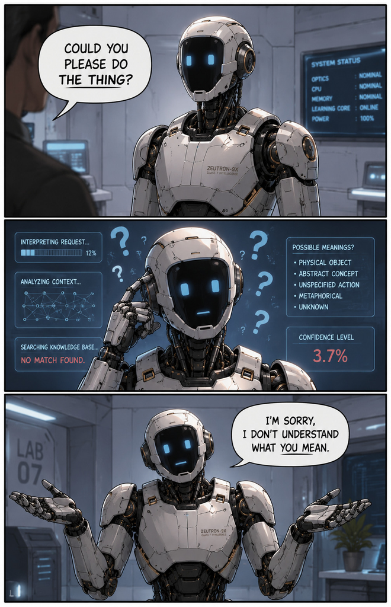

Generated w. OpenAI’s DALL·E

## Accountability

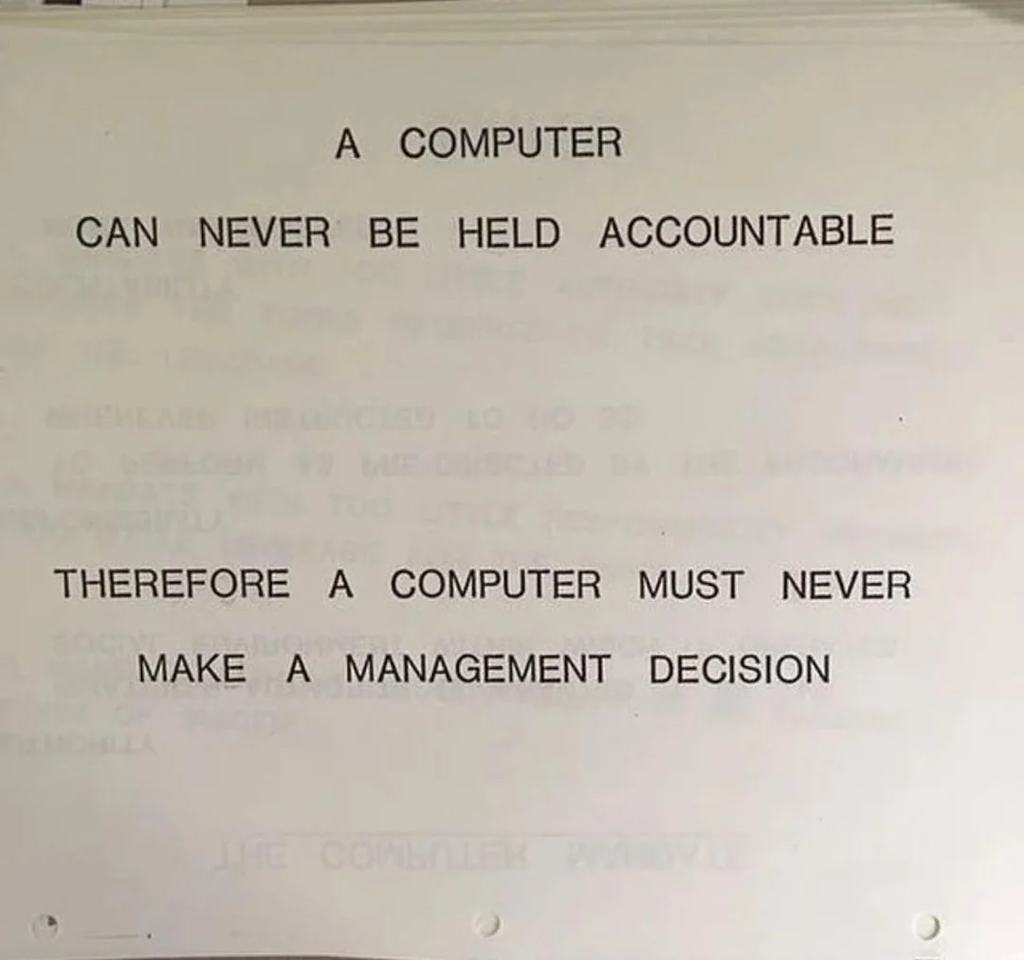

Internal training at IBM 1979

## Accountability

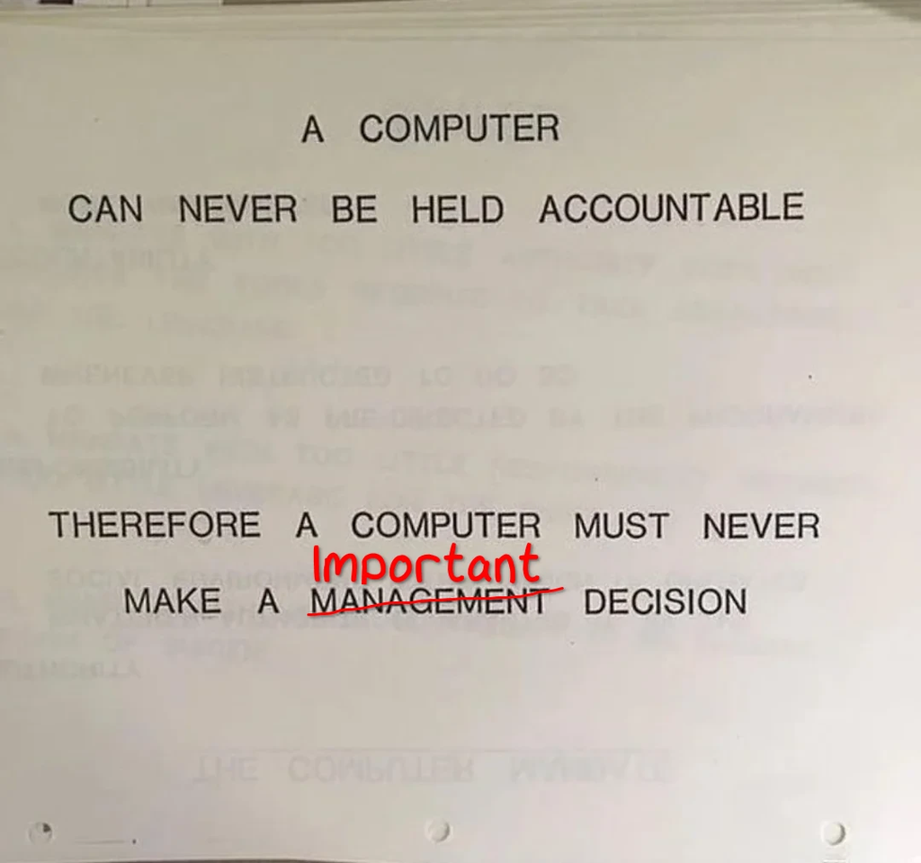

Internal training at IBM 1979; corrected for coding

**Caution**

If AI makes a mistake and you did not catch it, you are getting the bad grade/reputational damage

# `R` refresher

## Packages

- `R` organises its functions in packages (even base functions)
- Most packages must be installed (once) and attached (every new session)

```r
install.packages("tidyverse")
library(tidyverse)
```

## Accessing Functions

If you do not want to attach an entire package, you can use the Double Colon to only use a specific function:

```r
dplyr::select(iris, Sepal.Length)
```

```
    Sepal.Length
1            5.1
2            4.9
3            4.7
4            4.6
5            5.0
6            5.4
7            4.6
8            5.0
9            4.4
10           4.9
11           5.4
12           4.8
13           4.8
14           4.3
```

[output cut: 136 more lines]

Less often used, you can also do this with `library`:

```r
library("dplyr", include.only = c("select", "mutate"))
mutate(iris, sepal_length = Sepal.Length * 10) |>
  select(sepal_length)
```

## The Comprehensive R Archive Network (CRAN)

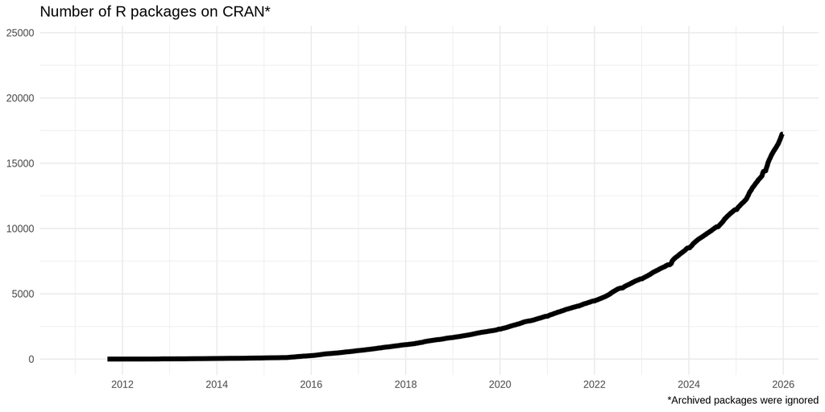

## Other sources?

- Rigorous policies and testing are also a downside
  - Developers hesitate to submit packages
  - Unmaintained (but functional) packages are removed from CRAN
- Alternative repositories are common:
  - GitHub and Gitlab (and SVN)
  - Bioconductor, R-universe 🚀, R-Forge and Omegahat

```r
remotes::install_github("JBGruber/paperboy")

# Install package from Bioconductor
BiocManager::install(c("GenomicRanges", "Organism.dplyr"))

# Install 'magick' from 'ropensci' universe
install.packages("magick", repos = "https://ropensci.r-universe.dev")
```

## Help!

One of the most important commands in `R`: `?`/`help`:

```r
?install.packages # And
?remotes::install_github # OR
help("install_github", package = "remotes")
```

All help files in `R` follow the same structure and principle (although not all help files contain all elements):

- **Title**
- **Description**
- **Usage**:very important: shows you the default values for all arguments (i.e., what is used if you do not set anything) and assumed order

```r
install_github("JBGruber/paperboy") # Same as
install_github(repo = "JBGruber/paperboy", ref = "HEAD") # Same as
install_github(ref = "HEAD", repo = "JBGruber/paperboy") # Not(!) same as
install_github("HEAD", "JBGruber/paperboy")
```

- **Arguments**: description of arguments in a function. One special argument is the `...` (called ellipsis or dots) which is passed to underlying function.

```r
install_github("JBGruber/paperboy", Ncpus = 6)
```

- **Details**: Usually not that important but this is the first place to look when a function is not doing what you expect
- **Examples**: where I usually start to learn a new function by looking at cases that certainly work (and then rewriting them for my purposes).

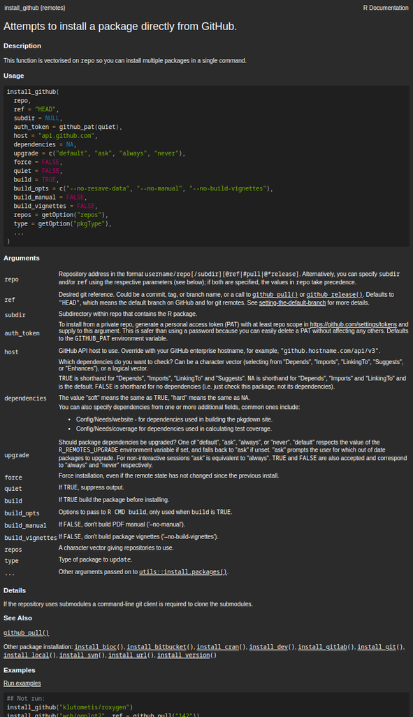

## Help!

- Google (“**ggplot2 r** remove legends”)
- Some good resources for answers:
  - stackoverflow.com (if you want to ask a question instead see [how to ask a good question](http://stackoverflow.com/help/how-to-ask) and use a [reproducible example](http://stackoverflow.com/questions/5963269))
  - R help list (stat.ethz.ch)
  - https://www.r-bloggers.com/ (collection of personal blog posts related to R – so quality varies)
- Claude/ChatGPT/Gemini/DeepSeek

## Functions

Functions are easy to define in `R`:

```r
new_fun <- function(x = 1) {
  out <- c(
    sum(x),
    mean(x),
    median(x)
  )
  return(out)
}
new_fun()
```

```
[1] 1 1 1
```

```r
vec <- c(1:10)
new_fun(x = vec)
```

```
[1] 55.0  5.5  5.5
```

Going through this bit by bit:

- **new_fun**: The name of the new function (convention: use something descriptive; don’t use `.` or CamelCase but `_` if you have multiple words)
- **<-**: The assignment operator.
- **function(x)**: Define arguments and defaults here.
- **{}**: Everything inside the curly brackets is the body of the function (code you are running when calling the function).
- **return()**: All objects created inside the function are immediately destroyed when the function finished running. Except what is put in `return()` (can be implicit).

## Data

In R, data is stored in objects. We will learn about different ways to do so tomorrow!

## Loops

### For loops

Iterate over a vector:

```r
x <- NULL
for (i in 1:10) {
  message(i)
  x <- c(x, i)
}
x
```

```
 [1]  1  2  3  4  5  6  7  8  9 10
```

### Apply loops

Apply function to each element of a vector/list:

```r
foo <- function(i, silent = FALSE) {
  if (!silent) {
    message(i)
  }
  return(i)
}
x <- lapply(1:10, foo)
unlist(x)
```

```
 [1]  1  2  3  4  5  6  7  8  9 10
```

### purrr::map loops

Also apply function to each element of a vector/list, but coerce types:

```r
foo <- function(i, silent = FALSE) {
  if (!silent) {
    message(i)
  }
  return(i)
}
x <- purrr::map_int(1:10, foo)
x
```

```
 [1]  1  2  3  4  5  6  7  8  9 10
```

## if

`if` can be used to conditionally run code:

```r
if (TRUE) {
  1 + 1
}
```

```
[1] 2
```

```r
if (FALSE) {
  1 + 1
}
```

Any code that evaluates to a logical (`TRUE`/`FALSE`) can be used:

```r
if (1 + 1 == 2) {
  "Hello!"
}
```

```
[1] "Hello!"
```

You can extend this with `else`, which is executed when the original condition is `FALSE`:

```r
if (1 + 2 == 2) {
  "Hello!"
} else {
  "Bye"
}
```

```
[1] "Bye"
```

## base `R`

Commonly people referring to *base* `R` mean all functions available when starting `R` but not loading any packages with `library(package)`.

```r
df <- mtcars # using a built-in example data.frame
table(df$cyl)
```

```
 4  6  8
11  7 14
```

```r
sum(df$cyl)
```

```
[1] 198
```

```r
mean(df$cyl)
```

```
[1] 6.1875
```

```r
dist(head(df)) # calculates euclidian distance between cases
```

```
                    Mazda RX4 Mazda RX4 Wag  Datsun 710 Hornet 4 Drive
Mazda RX4 Wag       0.6153251
Datsun 710         54.9086059    54.8915169
Hornet 4 Drive     98.1125212    98.0958939 150.9935191
Hornet Sportabout 210.3374396   210.3358546 265.0831615    121.0297564
Valiant            65.4717710    65.4392224 117.7547018     33.5508692
                  Hornet Sportabout
Mazda RX4 Wag
Datsun 710
Hornet 4 Drive
Hornet Sportabout
Valiant                 152.1241352
```

```r
tolower(row.names(df))
```

```
 [1] "mazda rx4"           "mazda rx4 wag"       "datsun 710"
 [4] "hornet 4 drive"      "hornet sportabout"   "valiant"
 [7] "duster 360"          "merc 240d"           "merc 230"
[10] "merc 280"            "merc 280c"           "merc 450se"
[13] "merc 450sl"          "merc 450slc"         "cadillac fleetwood"
[16] "lincoln continental" "chrysler imperial"   "fiat 128"
[19] "honda civic"         "toyota corolla"      "toyota corona"
[22] "dodge challenger"    "amc javelin"         "camaro z28"
[25] "pontiac firebird"    "fiat x1-9"           "porsche 914-2"
[28] "lotus europa"        "ford pantera l"      "ferrari dino"
[31] "maserati bora"       "volvo 142e"
```

Especially for simple operations and statistics, *base* is still great.

```r
model <- lm(hp ~ mpg, data = df) # simple linear regression
summary(model)
```

```
Call:
lm(formula = hp ~ mpg, data = df)

Residuals:
   Min     1Q Median     3Q    Max
-59.26 -28.93 -13.45  25.65 143.36

Coefficients:
            Estimate Std. Error t value Pr(>|t|)
(Intercept)   324.08      27.43  11.813 8.25e-13 ***
mpg            -8.83       1.31  -6.742 1.79e-07 ***
---
Signif. codes:  0 '***' 0.001 '**' 0.01 '*' 0.05 '.' 0.1 ' ' 1

Residual standard error: 43.95 on 30 degrees of freedom
Multiple R-squared:  0.6024,    Adjusted R-squared:  0.5892
F-statistic: 45.46 on 1 and 30 DF,  p-value: 1.788e-07
```

## base `R`

*base* also has a plotting system:

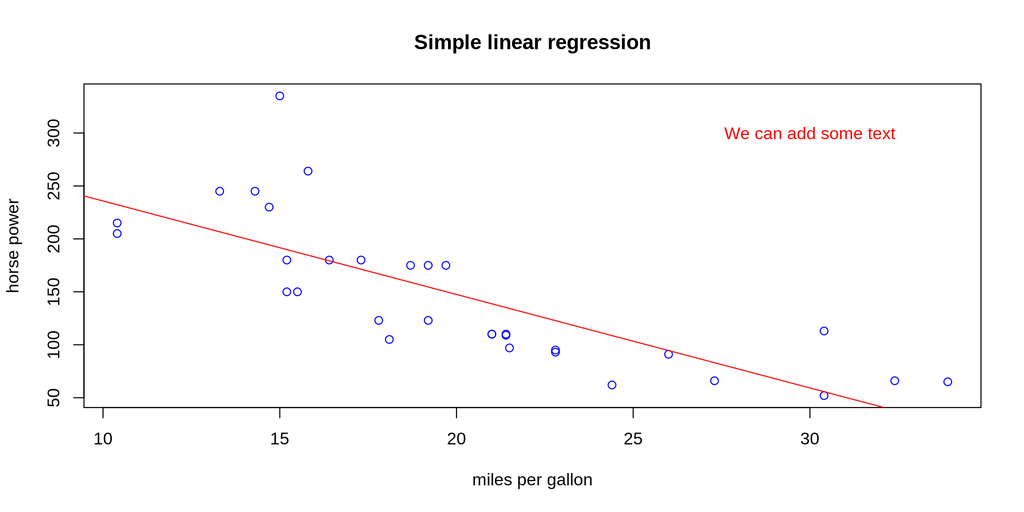

```r
plot(
  df$mpg,
  df$hp,
  col = "blue",
  ylab = "horse power",
  xlab = "miles per gallon",
  main = "Simple linear regression"
)
abline(model, col = "red")
text(30, 300, "We can add some text", col = "red")
```

## Tidyverse

### What is it?

- The official description: “The tidyverse is an opinionated collection of R packages designed for data science. All packages share an underlying design philosophy, grammar, and data structures”.
- The principle that gives the tidyverse its name is that of tidy data: “Each variable forms a column. Each observation forms a row.” (see [tidyr vignette](https://cran.r-project.org/web/packages/tidyr/vignettes/tidy-data.html) for more info)
- Seems trivial at first but as a principle can be quite consequential (e.g., it means that most object types are ignored and `data.frame`s are very dominant)
- Some coding principles attached to it (e.g., the pipe, functions as verbs that build on each other)

### The pipe

- Formerly `%>%`, now native in `R` as `|>`
- Forwards the result of one function to another
- Makes for much more readable code:

```r
transform(
  aggregate(. ~ cyl, data = subset(mtcars, hp > 100), FUN = function(x) {
    round(mean(x, 2))
  }),
  kpl = mpg * 0.4251
)
```

```
  cyl mpg disp  hp drat wt qsec vs am gear carb     kpl
1   4  26  108 111    4  2   18  1  1    4    2 11.0526
2   6  20  168 110    4  3   18  1  0    4    4  8.5020
3   8  15  350 192    3  4   17  0  0    3    4  6.3765
```

You Can make this more readable by createing intermediate objects:

```r
data1 <- subset(mtcars, hp > 100) # take subset of original data
data2 <- aggregate(. ~ cyl, data = data1, FUN = function(x) round(mean(x, 2))) # aggregate by taking rounded mean
transform(data2, kpl = mpg * 0.4251) # convert miles per gallon to kilometer per liter
```

```
  cyl mpg disp  hp drat wt qsec vs am gear carb     kpl
1   4  26  108 111    4  2   18  1  1    4    2 11.0526
2   6  20  168 110    4  3   18  1  0    4    4  8.5020
3   8  15  350 192    3  4   17  0  0    3    4  6.3765
```

Or you use the pipe:

```r
subset(mtcars, hp > 100) |>
  aggregate(. ~ cyl, data = _, FUN = function(x) round(mean(x, 2))) |>
  transform(kpl = mpg * 0.4251)
```

```
  cyl mpg disp  hp drat wt qsec vs am gear carb     kpl
1   4  26  108 111    4  2   18  1  1    4    2 11.0526
2   6  20  168 110    4  3   18  1  0    4    4  8.5020
3   8  15  350 192    3  4   17  0  0    3    4  6.3765
```

`tidyverse` functions are written with pipes in mind and are named as verbs with the goal to tell you exactly what they do:

```r
library(tidyverse)
mtcars |>
  filter(hp > 100) |>
  group_by(cyl) |>
  summarise(across(.cols = everything(), .fns = function(x) {
    x |> mean() |> round(2)
  })) |>
  mutate(kpl = mpg * 0.4251)
```

```
# A tibble: 3 × 12
    cyl   mpg  disp    hp  drat    wt  qsec    vs    am  gear  carb   kpl
  <dbl> <dbl> <dbl> <dbl> <dbl> <dbl> <dbl> <dbl> <dbl> <dbl> <dbl> <dbl>
1     4  25.9  108.  111   3.94  2.15  17.8  1     1     4.5   2    11.0
2     6  19.7  183.  122.  3.59  3.12  18.0  0.57  0.43  3.86  3.43  8.39
3     8  15.1  353.  209.  3.23  4     16.8  0     0.14  3.29  3.5   6.42
```

Note: You can interject the `View()` command at any line in a complicated pipeline to see the intermediate result in a spreadsheet-style data viewer.

### Special package `ggplot2`

- Completely overhauls the plotting system in `R`
- IMO: the best plotting system in any programming/data science language
- Implements the “Grammar of Graphics”: a language for describing custom plots instead of relying on predefined plotting functions
- The specific logic makes it harder to learn than other packages, but you can express essentially any plots in it (I highly recommend using [“ggplot2: Elegant Graphics for Data Analysis”](https://ggplot2-book.org/) to learn the package instead of individual tutorials)

## Exercises 2

1. Run ggplot(data = mtcars). What do you see and why?
2. In the function `pb_collect()` from `paperboy`, what do the arguments `ignore_fails` and `connections` do?
3. Write a function that takes a numeric vector of miles per gallon consumption data and converts it to kilometer per liter. If anything other than a numeric vector is entered, the function should display an error (hint: see ?stop).
4. In the code below, check the sizes of the intermediate objects with `object.size()`.

```r
file_link <- "https://raw.githubusercontent.com/shawn-y-sun/Customer_Analytics_Retail/main/purchase%20data.csv"
df <- read.csv(file_link)
filtered_df <- df[df$Age >= 50, ]
aggregated_df <- aggregate(
  filtered_df$Quantity,
  by = list(filtered_df$Day),
  FUN = sum
)
names(aggregated_df) <- c("day", "total_quantity")
aggregated_df[order(aggregated_df$total_quantity, decreasing = TRUE)[1:5], ]
```

```
    day total_quantity
162 162             73
460 460             73
123 123             61
183 183             60
340 340             57
```

5. How could the code above be improved if you only want the final result, the code should be readable and you care about memory usage?

# Literate Programming

## Background

> “The language in which we express our ideas has a strong influence on our thought processes.”

> ― Donald Ervin Knuth, Literate Programming
- When analysing data in R, a cornerstone of a good workflow is documenting what you are doing.
- The whole point of doing data analysis in a programming language rather than a point and click tool is reproducibility.
- Yet if your code does not run after a while and you don’t understand what you were doing when writing the code, it’s as if you had done your whole analysis in Excel!

## Advantages

1. Easier to **understand for yourself**: keep code and explanation together
2. Easier to **find** the code you are looking for: already use the figure and table captions from the article
3. Easier to **write coherent code**: organize code in the way your paper is organized too
4. Easier for your co-authors or **others to understand your scripts**
5. Easier to continue where you left off
6. Easier for others to **reproduce** your analyses

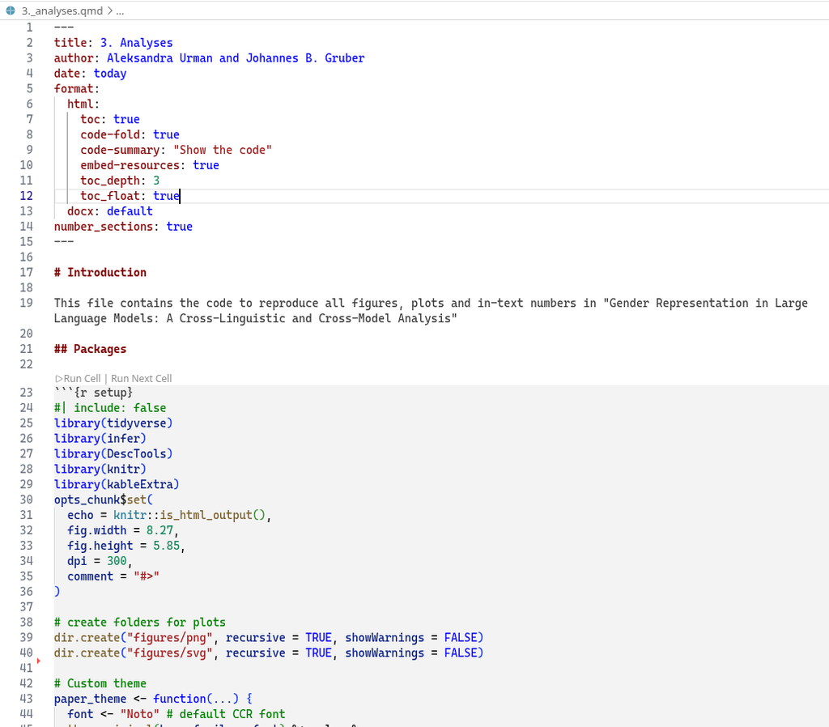

Quarto (and its predecessor R Markdown) was designe with literate programming in mind

## Exercises 3

1. Use the function `report_template()` from my package jbgtemplates to start a new report
2. Add some simple analysis in it and render
3. Play around with the [formats](https://quarto.org/docs/output-formats/all-formats.html) and produce at least a PDF and Word output of your document
4. Think about how the structure of the document enhances reproducibility

# Some other tricks

## The worst default setting in RStudio

[figure not shown]

The default setting to ask whether to save the current session is horrible. It eventually leads to you clicking yes, save the data and to the creation of a file called `.Rdata`. This file is loaded whenever you open RStudio! This makes RStudio slow and can lead to unexpected behaviour, even when you delete all objects in your environment with `rm(list = ls())`.

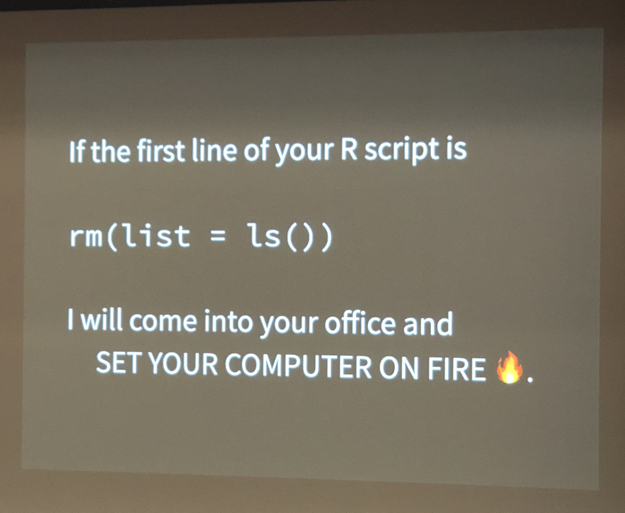

## Exercises 4

1. Change that setting NOW and look for the `.Rdata` in your project and home directory.

## Git some Version Control

Git is an extensive application and too much to go through. But you do not need all the functionality to make efficient use of it’s main promise: keeping track of what is happening in your projects and giving you the ability to revert to an older state of your project.

[figure not shown]

This screenshot shows the last months of my PhD, when I was furiously working on integrating comments from different people. Not only helped git to show me my progress nicely, I also did not have to worry about accidentally deleting anything that might still prove valuable. Especially towards the end, I often removed sections or copied them to other chapters. Whenever I could not find a specific section, I went back to the last commit when I could still remember where it was.

Additionally, GitHub offers some nice features to organise and plan projects around *issues*.

[figure not shown]

Here you can note down remaining problems and keep track of your progress. It keeps your head free for other things!

Learn more, e.g., at: https://happygitwithr.com/

# Homework

Many of you did not come to class to just scrape exercise pages. You probably had some initial data and/or research question in mind. Please write a short abstract on what you want to accomplish with the web scraping and data management skills you will learn here. The abstract should include:

- general goal
- research question
- (preliminary) assessment what data you need, what data can be found on the website and what potential research questions you have in mind.

Deadline: Tuesday midnight